# Homework 16

Yu-Jen Lin

#### b04b01036@ntu.edu.tw

#### ——————————————————————————————————————————————————–

## Use the data provided (modeldata.txt). The first two columns are x1 and x2, the column 3 to 5 represent codings for three class (y).

#### Loading package and data

5 hidden neurons

```r
library(neuralnet)
library(NeuralNetTools)

rawdata <- read.table("~/Desktop/modeldata.txt")

X <- as.matrix(cbind(1, rawdata[, 1:2]))
Y <- as.matrix(rawdata[, 3:5])

head(X)
```

```
##      1        V1        V2
## [1,] 1 -0.010858 -0.156341
## [2,] 1  0.333771 -0.001121
## [3,] 1 -0.136610 -0.334077
## [4,] 1  0.295694  0.136831
## [5,] 1 -0.426438 -0.086389
## [6,] 1  0.769671  0.428975
```

```r
head(Y)
```

```
##      V3 V4 V5
## [1,] -1 -1  1
## [2,] -1  1 -1
## [3,] -1 -1  1
## [4,] -1  1 -1
## [5,]  1 -1 -1
## [6,] -1 -1  1
```

```r
Neuralnet <- neuralnet(Y[,1] + Y[,2] + Y[,3] ~ X[,1] + X[,2], data = rawdata, hidden = 5)

plot(Neuralnet)

# Red lines: positive weights
# Blue lines: negative weights
plotnet(Neuralnet, pos_col = "red", neg_col = "blue", alpha_val = 0.5)
```

[output not shown]

#### Ativation function - tanh

```r
# use tanh as my activation function
derivative_tanh <- function(x) {1 - tanh(x)^2}  # derivative of tanh(x)
```

## Write your own MLP. Use off-line learning, learning rate=0.001, learning time=1000 step, # of hidden neuron=5, use tanh as your activation function. Plot MSE vs learning steps. Calculate the min(MSE) and associated optimal weights.

(NOTE: you should try different initial conditions several times to check whether you get trapped in the local minimum.)

#### ——————————————————————————————————————————————————–

# [First try] learning rate = 0.001, learning time = 1000 steps

#### Initially, I use the value given by professor to do the following calculation. Yet, I found this setting might not be so suitable for this data. As a result, I will use another initial conditions later.

#### Initial settings

```r
n = 600  # data points
learning_steps <- 1000  # number of learning step
learning_rate <- 0.001  # learning rate

# Need to add bias term.
```

```r
# hidden unit value
a <- matrix(0, nrow=n, ncol=2)  # hidden neuron 1
b <- matrix(0, nrow=n, ncol=2)  # hidden neuron 2
c <- matrix(0, nrow=n, ncol=2)  # hidden neuron 3
d <- matrix(0, nrow=n, ncol=2)  # hidden neuron 4
e <- matrix(0, nrow=n, ncol=2)  # hidden neuron 5

# coefficient 1
a1 <- matrix(0, nrow=learning_steps, ncol=2+1)  # hidden neuron 1, unit 1
b1 <- matrix(0, nrow=learning_steps, ncol=2+1)  # hidden neuron 2, unit 1
c1 <- matrix(0, nrow=learning_steps, ncol=2+1)  # hidden neuron 3, unit 1
d1 <- matrix(0, nrow=learning_steps, ncol=2+1)  # hidden neuron 4, unit 1
e1 <- matrix(0, nrow=learning_steps, ncol=2+1)  # hidden neuron 5, unit 1

# coefficient 2
a2 <- matrix(0, nrow=learning_steps, ncol=2+1)  # hidden neuron 1, unit 2
b2 <- matrix(0, nrow=learning_steps, ncol=2+1)  # hidden neuron 2, unit 2
c2 <- matrix(0, nrow=learning_steps, ncol=2+1)  # hidden neuron 3, unit 2
d2 <- matrix(0, nrow=learning_steps, ncol=2+1)  # hidden neuron 4, unit 2
e2 <- matrix(0, nrow=learning_steps, ncol=2+1)  # hidden neuron 5, unit 2

# final output weights
f1 <- matrix(0, nrow=learning_steps, ncol=2+1)
f2 <- matrix(0, nrow=learning_steps, ncol=2+1)
f3 <- matrix(0, nrow=learning_steps, ncol=2+1)

# final output
y.result <- matrix(0, nrow=learning_steps, ncol=3)
```

#### Calculating MSE

```r
# mse
mse = matrix(0, nrow=learning_steps, ncol=3)

# set initial values
a1[1, ] = runif(3, -0.5, 0.5)
b1[1, ] = runif(3, -0.5, 0.5)
c1[1, ] = runif(3, -0.5, 0.5)
d1[1, ] = runif(3, -0.5, 0.5)
e1[1, ] = runif(3, -0.5, 0.5)

a2[1, ] = runif(3, -0.5, 0.5)
b2[1, ] = runif(3, -0.5, 0.5)
c2[1, ] = runif(3, -0.5, 0.5)
d2[1, ] = runif(3, -0.5, 0.5)
e2[1, ] = runif(3, -0.5, 0.5)

f1[1, ] = runif(3, -0.5, 0.5)
f2[1, ] = runif(3, -0.5, 0.5)
f3[1, ] = runif(3, -0.5, 0.5)

# Now we compute MSE for step 1
a = tanh(X%*%cbind(a1[1, ], a2[1, ]))
b = tanh(cbind(1, a)%*%cbind(b1[1, ], b2[1, ]))
c = tanh(cbind(1, b)%*%cbind(c1[1, ], c2[1, ]))
d = tanh(cbind(1, c)%*%cbind(d1[1, ], d2[1, ]))
e = tanh(cbind(1, d)%*%cbind(e1[1, ], e2[1, ]))
y.result = tanh(cbind(1, e)%*%cbind(f1[1, ], f2[1, ], f3[1, ]))

mse[1, ] = diag(t(Y - y.result)%*%(Y - y.result))/n
```

#### Coefficients

```r
for (i in 1:(learning_steps-1)) {
  a = tanh(X%*%cbind(a1[i, ], a2[i, ]))
  b = tanh(cbind(1, a)%*%cbind(b1[i, ], b2[i, ]))
  c = tanh(cbind(1, b)%*%cbind(c1[i, ], c2[i, ]))
  d = tanh(cbind(1, c)%*%cbind(d1[i, ], d2[i, ]))
  e = tanh(cbind(1, d)%*%cbind(e1[i, ], e2[i, ]))
  y.result = tanh(cbind(1, e)%*%cbind(f1[i, ], f2[i, ], f3[i, ]))

  mse[i, ] = diag(t(Y - y.result)%*%(Y - y.result))/n

  delta1 = derivative_tanh(cbind(1, e)%*%cbind(f1[i, ], f2[i, ], f3[i, ]))*(Y - y.result)
  delta2 = derivative_tanh(cbind(1, d)%*%cbind(e1[i, ], e2[i, ]))*
    (delta1%*%t(cbind(f1[i, ], f2[i, ], f3[i, ])[-1, ]))
  delta3 = derivative_tanh(cbind(1, c)%*%cbind(d1[i, ], d2[i, ]))*
    (delta2%*%t(cbind(e1[i, ], e2[i, ])[-1, ]))
  delta4 = derivative_tanh(cbind(1, b)%*%cbind(c1[i, ], c2[i, ]))*
    (delta3%*%t(cbind(d1[i, ], d2[i, ])[-1, ]))
  delta5 = derivative_tanh(cbind(1, a)%*%cbind(b1[i, ], b2[i, ]))*
    (delta4%*%t(cbind(c1[i, ], c2[i, ])[-1, ]))
  delta6 = derivative_tanh(X%*%cbind(a1[i, ], a2[i, ]))*
    (delta5%*%t(cbind(b1[i, ], b2[i, ])[-1, ]))

  f1[(i+1), ] = learning_rate*delta1[, 1]%*%cbind(1, e)/n + f1[i, ]
  f2[(i+1), ] = learning_rate*delta1[, 2]%*%cbind(1, e)/n + f2[i, ]
  f3[(i+1), ] = learning_rate*delta1[, 3]%*%cbind(1, e)/n + f3[i, ]

  e1[(i+1), ] = learning_rate*delta2[, 1]%*%cbind(1, d)/n + e1[i, ]
  d1[(i+1), ] = learning_rate*delta3[, 1]%*%cbind(1, c)/n + d1[i, ]
  c1[(i+1), ] = learning_rate*delta4[, 1]%*%cbind(1, b)/n + c1[i, ]
  b1[(i+1), ] = learning_rate*delta5[, 1]%*%cbind(1, a)/n + b1[i, ]
  a1[(i+1), ] = learning_rate*delta6[, 1]%*%X/n + a1[i, ]

  e2[(i+1), ] = learning_rate*delta2[, 2]%*%cbind(1, d)/n + e2[i, ]
  d2[(i+1), ] = learning_rate*delta3[, 2]%*%cbind(1, c)/n + d2[i, ]
  c2[(i+1), ] = learning_rate*delta4[, 2]%*%cbind(1, b)/n + c2[i, ]
  b2[(i+1), ] = learning_rate*delta5[, 2]%*%cbind(1, a)/n + b2[i, ]
  a2[(i+1), ] = learning_rate*delta6[, 2]%*%X/n + a2[i, ]
}
```

```r
head(y.result)  # looks not resonable
```

```
##               [,1]          [,2]          [,3]
## [1,] -0.3889101893 -0.1289078266 -0.1336958515
## [2,] -0.3887860111 -0.1292271619 -0.1343988409
## [3,] -0.3891569582 -0.1288454925 -0.1333403136
## [4,] -0.3885391692 -0.1291235136 -0.1344522129
## [5,] -0.3886604565 -0.1284551853 -0.1331168885
## [6,] -0.3882577542 -0.1295214399 -0.1354521277
```

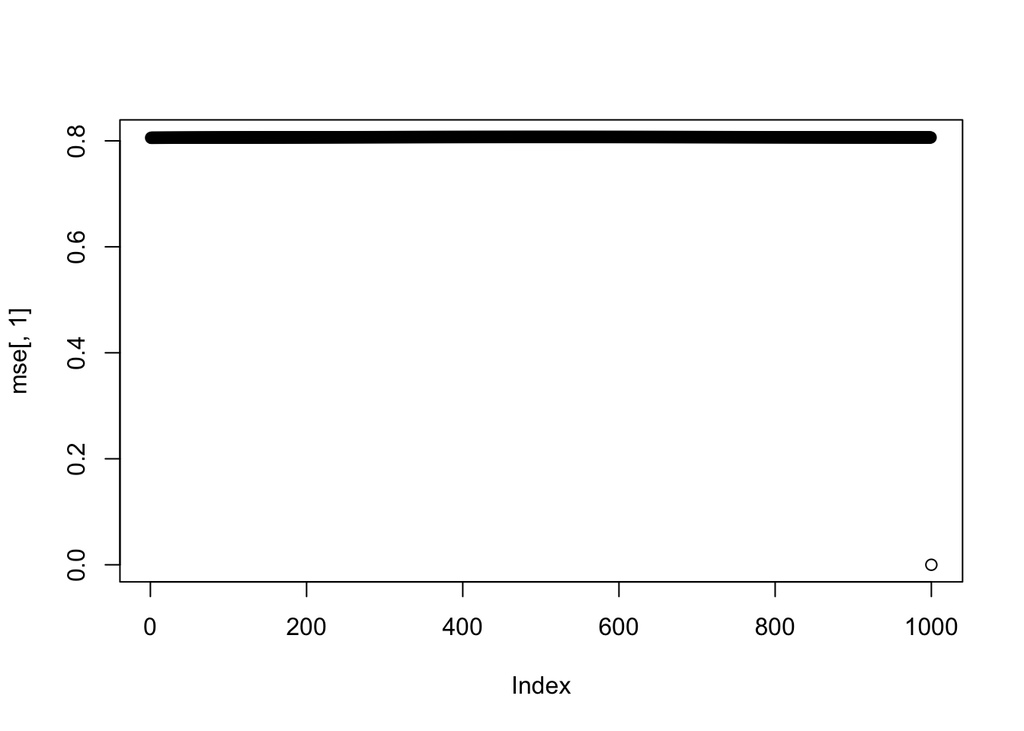

```r
plot(mse[, 1]) # MSE declines slowly, remaining in a high value,
```

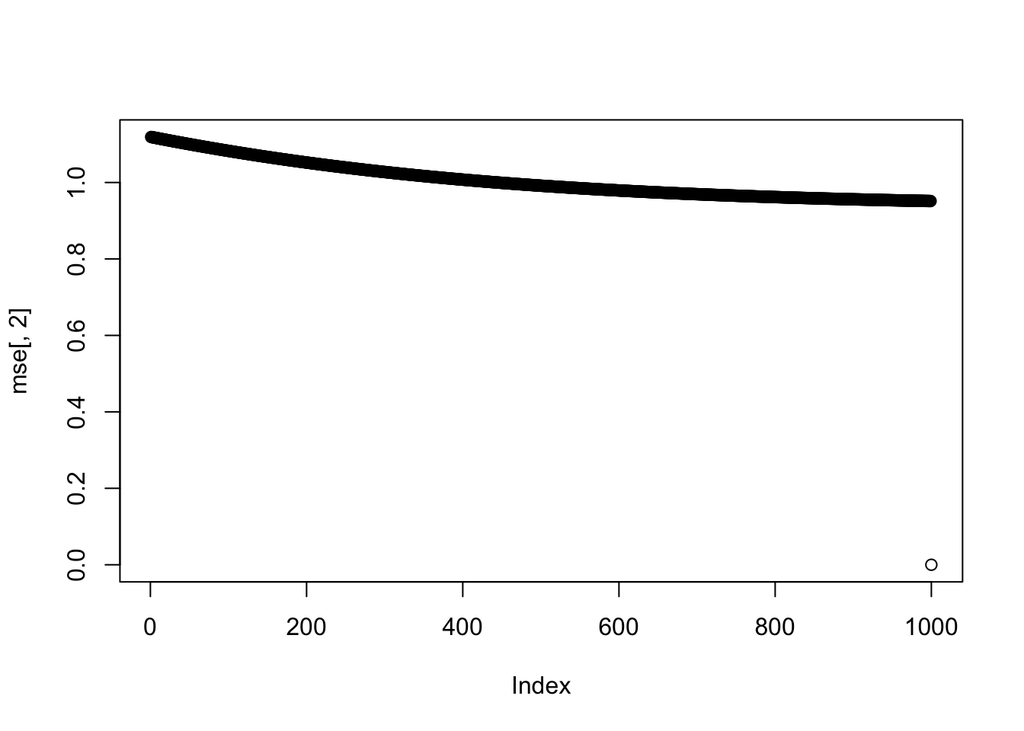

```r
plot(mse[, 2])
```

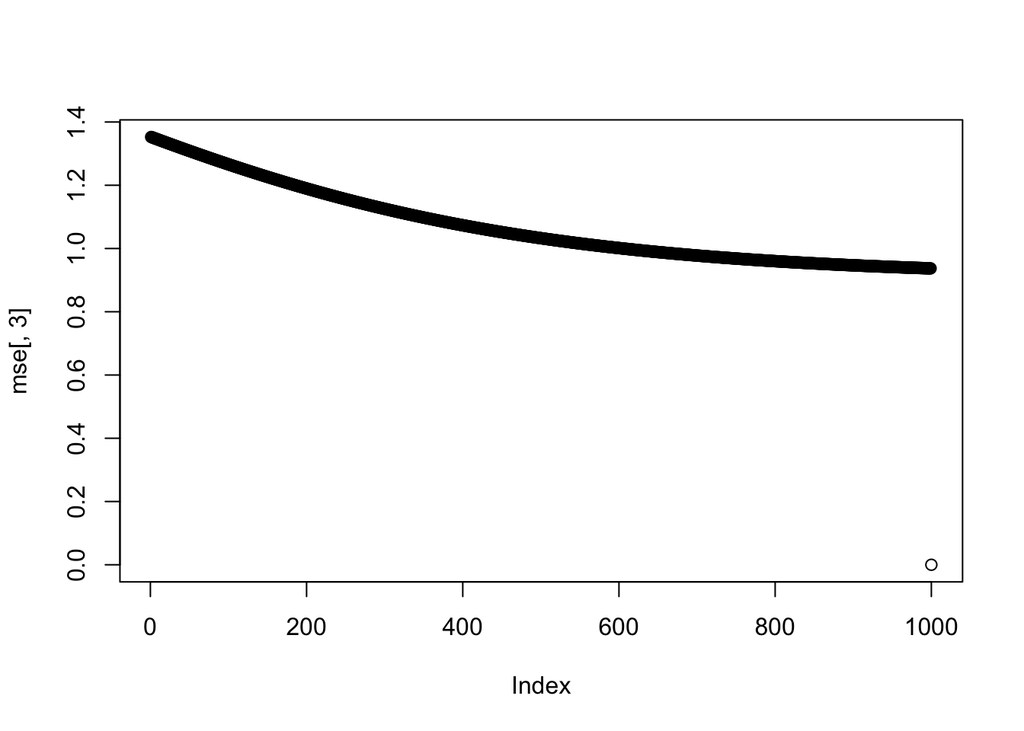

```r
plot(mse[, 3])
```

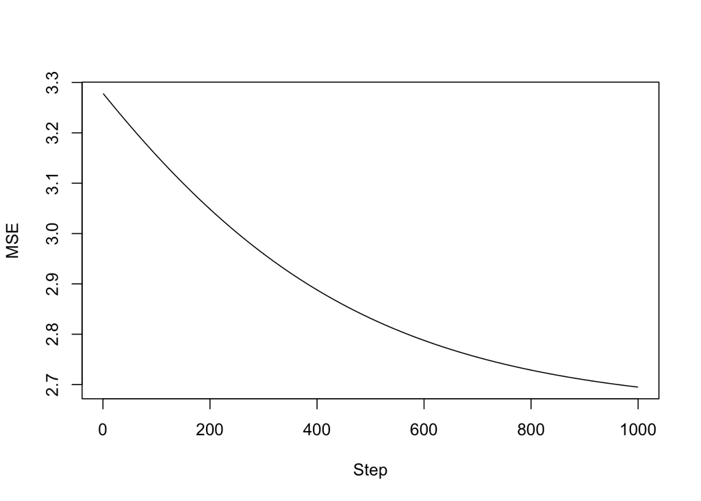

```r
plot(apply(mse, 1, sum)[-learning_steps], type='l', xlab='Step', ylab='MSE')
```

In above figures, we can see that MSE are all very high when learning rate = 0.001, learning time = 1000 steps. In other words, this means the initial condition should be adjust. Consequently, I reset the initial condition and run above scripts again.

#### ——————————————————————————————————————————————————–

# [Second try] learning rate = 0.5, learning time = 5000 steps

#### Try higher learning rate and bigger learning steps.

```r
# adjust the initial condition
learning_steps = 5000
learning_rate = 0.5

# hidden unit value
a <- matrix(0, nrow=n, ncol=2)  # hidden neuron 1
b <- matrix(0, nrow=n, ncol=2)  # hidden neuron 2
c <- matrix(0, nrow=n, ncol=2)  # hidden neuron 3
d <- matrix(0, nrow=n, ncol=2)  # hidden neuron 4
e <- matrix(0, nrow=n, ncol=2)  # hidden neuron 5

# coefficient 1
a1 <- matrix(0, nrow=learning_steps, ncol=2+1)  # hidden neuron 1, unit 1
b1 <- matrix(0, nrow=learning_steps, ncol=2+1)  # hidden neuron 2, unit 1
c1 <- matrix(0, nrow=learning_steps, ncol=2+1)  # hidden neuron 3, unit 1
d1 <- matrix(0, nrow=learning_steps, ncol=2+1)  # hidden neuron 4, unit 1
e1 <- matrix(0, nrow=learning_steps, ncol=2+1)  # hidden neuron 5, unit 1

# coefficient 2
a2 <- matrix(0, nrow=learning_steps, ncol=2+1)  # hidden neuron 1, unit 2
b2 <- matrix(0, nrow=learning_steps, ncol=2+1)  # hidden neuron 2, unit 2
c2 <- matrix(0, nrow=learning_steps, ncol=2+1)  # hidden neuron 3, unit 2
d2 <- matrix(0, nrow=learning_steps, ncol=2+1)  # hidden neuron 4, unit 2
e2 <- matrix(0, nrow=learning_steps, ncol=2+1)  # hidden neuron 5, unit 2

# final output weights
f1 <- matrix(0, nrow=learning_steps, ncol=2+1)
f2 <- matrix(0, nrow=learning_steps, ncol=2+1)
f3 <- matrix(0, nrow=learning_steps, ncol=2+1)

# final output
y.result <- matrix(0, nrow=learning_steps, ncol=3)
```

#### Calculating MSE

```r
# mse
mse = matrix(0, nrow=learning_steps, ncol=3)

# set initial values
a1[1, ] = runif(3, -0.5, 0.5)
b1[1, ] = runif(3, -0.5, 0.5)
c1[1, ] = runif(3, -0.5, 0.5)
d1[1, ] = runif(3, -0.5, 0.5)
e1[1, ] = runif(3, -0.5, 0.5)

a2[1, ] = runif(3, -0.5, 0.5)
b2[1, ] = runif(3, -0.5, 0.5)
c2[1, ] = runif(3, -0.5, 0.5)
d2[1, ] = runif(3, -0.5, 0.5)
e2[1, ] = runif(3, -0.5, 0.5)

f1[1, ] = runif(3, -0.5, 0.5)
f2[1, ] = runif(3, -0.5, 0.5)
f3[1, ] = runif(3, -0.5, 0.5)

# Now we compute MSE for step 1
a = tanh(X%*%cbind(a1[1, ], a2[1, ]))
b = tanh(cbind(1, a)%*%cbind(b1[1, ], b2[1, ]))
c = tanh(cbind(1, b)%*%cbind(c1[1, ], c2[1, ]))
d = tanh(cbind(1, c)%*%cbind(d1[1, ], d2[1, ]))
e = tanh(cbind(1, d)%*%cbind(e1[1, ], e2[1, ]))
y.result = tanh(cbind(1, e)%*%cbind(f1[1, ], f2[1, ], f3[1, ]))

mse[1, ] = diag(t(Y - y.result)%*%(Y - y.result))/n
```

#### Coefficients

```r
for (i in 1:(learning_steps-1)) {
  a = tanh(X%*%cbind(a1[i, ], a2[i, ]))
  b = tanh(cbind(1, a)%*%cbind(b1[i, ], b2[i, ]))
  c = tanh(cbind(1, b)%*%cbind(c1[i, ], c2[i, ]))
  d = tanh(cbind(1, c)%*%cbind(d1[i, ], d2[i, ]))
  e = tanh(cbind(1, d)%*%cbind(e1[i, ], e2[i, ]))
  y.result = tanh(cbind(1, e)%*%cbind(f1[i, ], f2[i, ], f3[i, ]))

  mse[i, ] = diag(t(Y - y.result)%*%(Y - y.result))/n

  delta1 = derivative_tanh(cbind(1, e)%*%cbind(f1[i, ], f2[i, ], f3[i, ]))*(Y - y.result)
  delta2 = derivative_tanh(cbind(1, d)%*%cbind(e1[i, ], e2[i, ]))*
    (delta1%*%t(cbind(f1[i, ], f2[i, ], f3[i, ])[-1, ]))
  delta3 = derivative_tanh(cbind(1, c)%*%cbind(d1[i, ], d2[i, ]))*
    (delta2%*%t(cbind(e1[i, ], e2[i, ])[-1, ]))
  delta4 = derivative_tanh(cbind(1, b)%*%cbind(c1[i, ], c2[i, ]))*
    (delta3%*%t(cbind(d1[i, ], d2[i, ])[-1, ]))
  delta5 = derivative_tanh(cbind(1, a)%*%cbind(b1[i, ], b2[i, ]))*
    (delta4%*%t(cbind(c1[i, ], c2[i, ])[-1, ]))
  delta6 = derivative_tanh(X%*%cbind(a1[i, ], a2[i, ]))*
    (delta5%*%t(cbind(b1[i, ], b2[i, ])[-1, ]))

  f1[(i+1), ] = learning_rate*delta1[, 1]%*%cbind(1, e)/n + f1[i, ]
  f2[(i+1), ] = learning_rate*delta1[, 2]%*%cbind(1, e)/n + f2[i, ]
  f3[(i+1), ] = learning_rate*delta1[, 3]%*%cbind(1, e)/n + f3[i, ]

  e1[(i+1), ] = learning_rate*delta2[, 1]%*%cbind(1, d)/n + e1[i, ]
  d1[(i+1), ] = learning_rate*delta3[, 1]%*%cbind(1, c)/n + d1[i, ]
  c1[(i+1), ] = learning_rate*delta4[, 1]%*%cbind(1, b)/n + c1[i, ]
  b1[(i+1), ] = learning_rate*delta5[, 1]%*%cbind(1, a)/n + b1[i, ]
  a1[(i+1), ] = learning_rate*delta6[, 1]%*%X/n + a1[i, ]

  e2[(i+1), ] = learning_rate*delta2[, 2]%*%cbind(1, d)/n + e2[i, ]
  d2[(i+1), ] = learning_rate*delta3[, 2]%*%cbind(1, c)/n + d2[i, ]
  c2[(i+1), ] = learning_rate*delta4[, 2]%*%cbind(1, b)/n + c2[i, ]
  b2[(i+1), ] = learning_rate*delta5[, 2]%*%cbind(1, a)/n + b2[i, ]
  a2[(i+1), ] = learning_rate*delta6[, 2]%*%X/n + a2[i, ]
}
```

```r
head(y.result)  # looks quite good
```

```
##               [,1]          [,2]          [,3]
## [1,] -0.9906494637 -0.6773481481  0.6454614270
## [2,] -0.9988529766  0.3450816561 -0.3506333289
## [3,] -0.9575073738 -0.9256508937  0.8974875658
## [4,] -0.9988529012  0.3450595956 -0.3506260096
## [5,]  0.9912784124 -0.9929136316 -0.9899015658
## [6,] -0.9988527379  0.3450117308 -0.3506099687
```

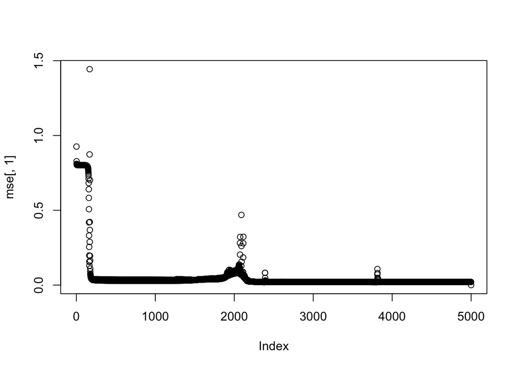

```r
# MSE declines faster and gets closer to zero than previous results.
plot(mse[, 1])
```

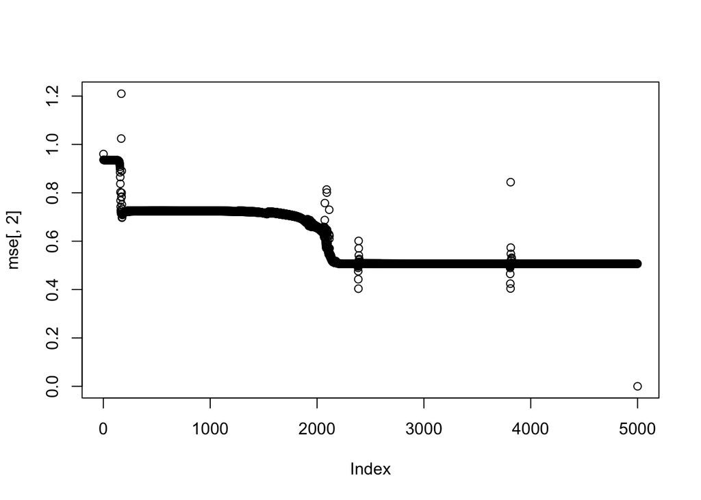

```r
plot(mse[, 2])
```

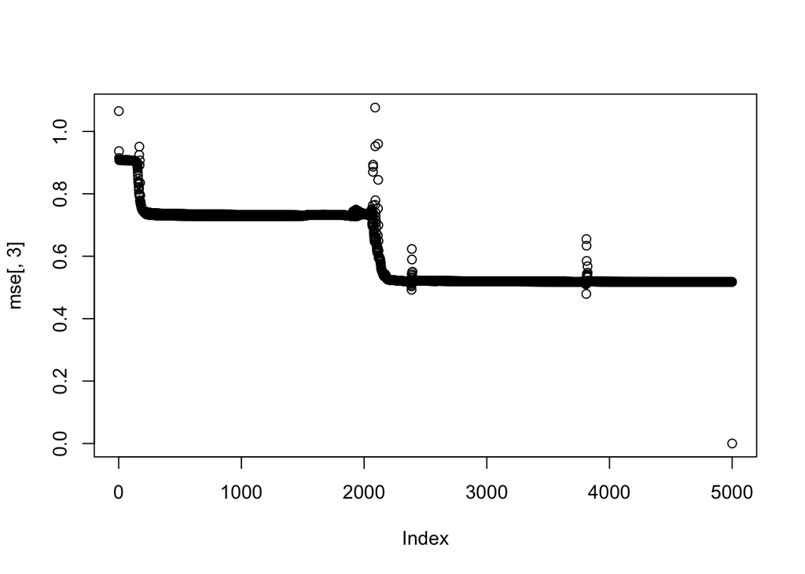

```r
plot(mse[, 3])
```

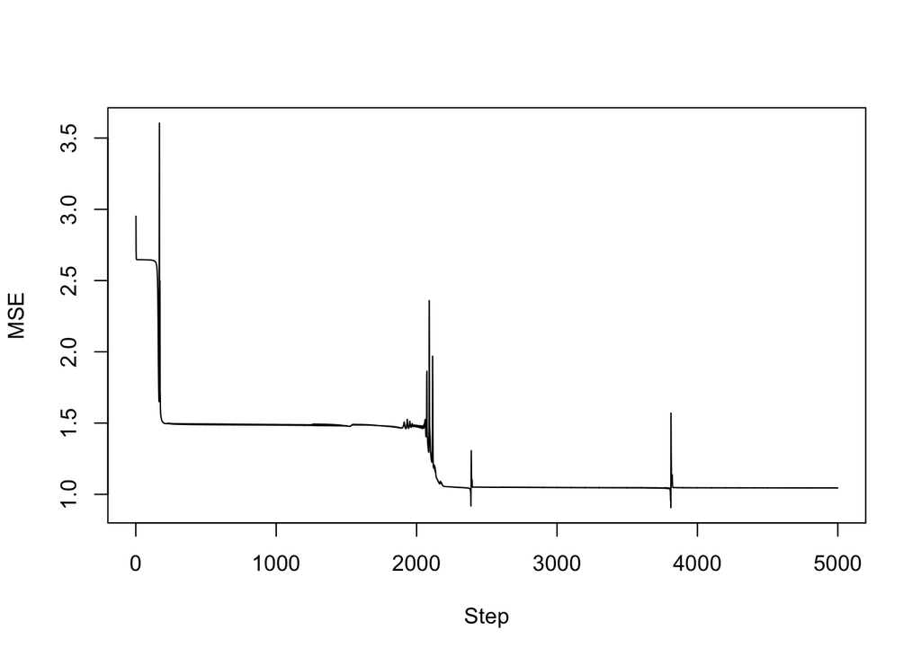

```r
plot(apply(mse, 1, sum)[-learning_steps], type='l', xlab='Step', ylab='MSE')
```

```r
# find the minimum MSE
min.mse <- which.min(apply(mse, 1, sum)[-learning_steps])

# compute the final codings with minimal MSE
S = tanh(X%*%cbind(a1[min.mse, ], a2[min.mse, ]))
H = tanh(cbind(1, a)%*%cbind(b1[min.mse, ], b2[min.mse, ]))
P = tanh(cbind(1, b)%*%cbind(c1[min.mse, ], c2[min.mse, ]))
Q = tanh(cbind(1, c)%*%cbind(d1[min.mse, ], d2[min.mse, ]))
R = tanh(cbind(1, d)%*%cbind(e1[min.mse, ], e2[min.mse, ]))
y.result = tanh(cbind(1, e)%*%cbind(f1[min.mse, ], f2[min.mse, ], f3[min.mse, ]))

# coefficients with minimal MSE
a1[min.mse, ]
```

```
## [1] 0.171955203 1.491329092 2.546645084
```

```r
b1[min.mse, ]
```

```
## [1] -0.6684789975  2.2762395795 -1.2704579985
```

```r
c1[min.mse, ]
```

```
## [1] -0.6318803446 -0.6516306702  1.8473431125
```

```r
d1[min.mse, ]
```

```
## [1]  0.01571919196 -0.63337397205 -2.06697080344
```

```r
e1[min.mse, ]
```

```
## [1] -0.8698397170 -0.4434251553 -2.2758025274
```

```r
a2[min.mse, ]
```

```
## [1] -1.6565346235 -3.7190027543  0.9175233611
```

```r
b2[min.mse, ]
```

```
## [1] 1.095617487 1.232300126 1.020331665
```

```r
c2[min.mse, ]
```

```
## [1]  0.04244469982 -2.20824526480 -1.26993583731
```

```r
d2[min.mse, ]
```

```
## [1] -0.04108665093 -1.53998177316 -0.58442672642
```

```r
e2[min.mse, ]
```

```
## [1] -0.8326497596  1.5005622350  1.8721984699
```

```r
f1[min.mse, ]
```

```
## [1] -0.5163289373  2.2541624513 -0.8533395227
```

```r
f2[min.mse, ]
```

```
## [1] -1.166625659 -0.530623266  1.185087399
```

```r
f3[min.mse, ]
```

```
## [1] -1.451880294 -2.198926423 -1.180947126
```

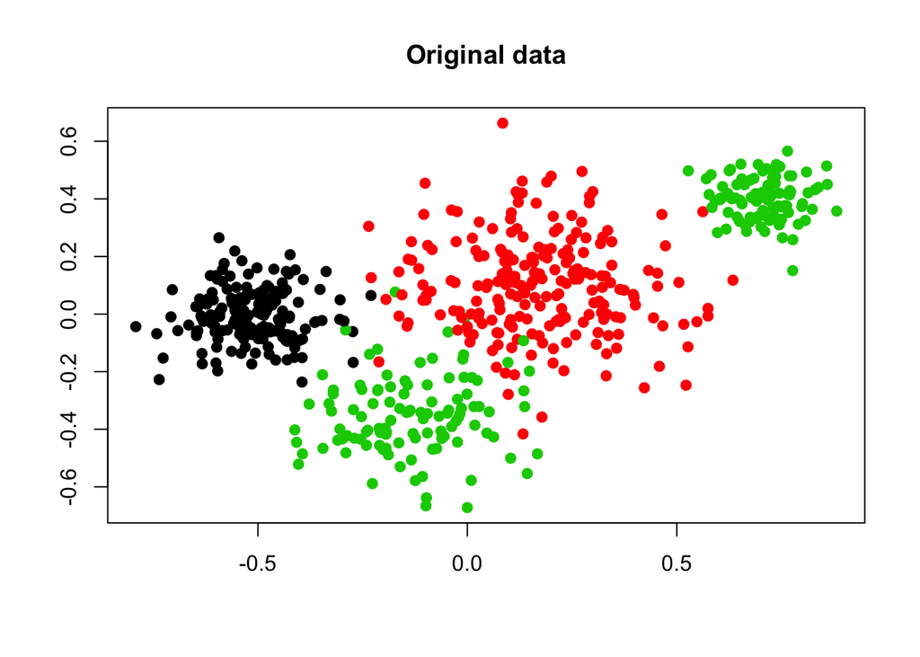

```r
# original data
y1 = ifelse(rawdata[, 3]==1, 1, 0)
y2 = ifelse(rawdata[, 4]==1, 2, 0)
y3 = ifelse(rawdata[, 5]==1, 3, 0)
y <- y1 + y2 + y3
plot(X[, -1], col=y, pch=19, xlab='', ylab='', main="Original data")
```

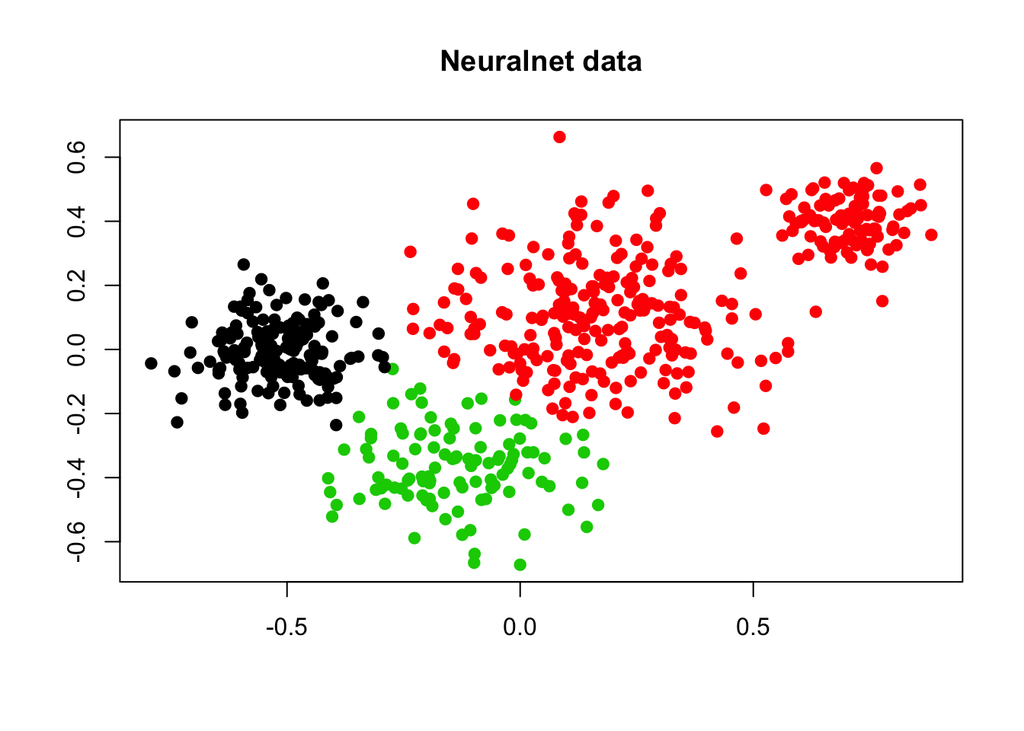

```r
# Neuralnet data
y1 = ifelse(floor(y.result)[, 1]==0, 1, 0)
y2 = ifelse(floor(y.result)[, 2]==0, 2, 0)
y3 = ifelse(floor(y.result)[, 3]==0, 3, 0)
y <- y1 + y2 + y3

# Most of the data are correctly classify. But still, we can found that some points are classified into wrong classes in the upper-right corner.
plot(X[, -1], col=y, pch=19, xlab='', ylab='', main="Neuralnet data")
```